# Global and local influence analysis with the *mixpoissonreg* package

Alexandre B. Simas

2020-12-31

# Global Influence

In the *mixpoissonreg* package the following global influence methods are implemented: `hatvalues`, `cooks.distance` and `influence`. Below, we discuss the implementations of these methods in detail.

## `hatvalues` method

To define “hat values” for mixed Poisson regression models, we follow [Zhu et al. (2001)](https://www.jstor.org/stable/2673442) to consider the negative of the hessian of the Q-function as weight matrix, and follow [Pregibon (1981)](https://projecteuclid.org/euclid.aos/1176345513) to define the “hat” matrix with respect to this weight matrix. We can consider the hessian of the Q-function with respect to mean-related parameters, which is the default. We can also consider the hessian of the Q-function with respect to the precision-related parameters to give rise to hat values related to the precision parameters.

To obtain the mean-related hat values one simply calls the `hatvalues` method:

```r
library(mixpoissonreg)

fit <- mixpoissonreg(daysabs ~ gender + math + prog | gender + math + prog,
                        data = Attendance)

head(hatvalues(fit))
```

```
#>           1           2           3           4           5           6
#> 0.009079739 0.006988288 0.004624419 0.006642724 0.009645108 0.026264888
```

To obtain precision-related hat values one must set `parameters` to “precision”:

```r
head(hatvalues(fit, parameters = "precision"))
```

```
#>           1           2           3           4           5           6
#> 0.003308865 0.004137420 0.015968704 0.012503542 0.020321253 0.007444368
```

## `cooks.distance` method

The implementation of the `cooks.distance` method for `mixpoissonreg` models contains several “Cook’s distance”-like measures. More precisely, it contains the standard Cook’s distance, the generalized Cook’s distance, the likelihood displacement and the Q-displacement.

### Cook’s distance

The implementation of the standard Cook’s distance uses the usual formula for Cook’s distance in terms of the “hat” matrix, where the “hat” matrix is the one given above. The standard Cook’s distance returned by default in the `cooks.distance` method. So, to obtain Cook’s distance, we simply call the `cooks.distance` method:

```r
head(cooks.distance(fit))
```

```
#>            1            2            3            4            5            6
#> 7.412875e-05 1.938615e-04 6.180147e-04 6.839705e-04 1.170998e-03 5.061612e-03
```

Since there is also a “hat” matrix with respect to the precision parameters, we may compute Cook’s distance using the hat values with respect to the precision parameters. To compute Cook’s distance with the “hat” matrix with respect to the precision parameters we simply set the `hat` argument to “precision”:

```r
head(cooks.distance(fit, hat = "precision"))
```

```
#>            1            2            3            4            5            6
#> 0.0000267023 0.0001141196 0.0021835715 0.0013027589 0.0025212380 0.0013807438
```

### generalized Cook’s distance and Q-displacement

The Generalized Cook’s distance and Q-displacement (also called Q-distance) for EM-based models were defined in [Zhu et al. (2001)](https://www.jstor.org/stable/2673442) and computed for mixed Poisson regression models in [Barreto-Souza and Simas (2016)](https://doi.org/10.1007/s11222-015-9601-6). We implemented first-order approximation to these quantities to make it computationally feasible. These first-order approximations are available in [Barreto-Souza and Simas (2016)](https://doi.org/10.1007/s11222-015-9601-6). We also provide versions of generalized Cook’s distance for mean-related or precision-related parameters, whose details can be found in [Barreto-Souza and Simas (2016)](https://doi.org/10.1007/s11222-015-9601-6).

To compute the generalized Cook’s distance with respect to the mean and precision parameters jointly, simply set the `type` argument to “GCD”:

```r
head(cooks.distance(fit, type = "GCD"))
```

```
#>           1           2           3           4           5           6
#> 0.004246910 0.002821262 0.002072318 0.001018639 0.001979334 0.003445146
```

To compute the generalized Cook’s distance with respect to the mean-related parameters, set the `type` argument to “GCDmean”:

```r
head(cooks.distance(fit, type = "GCDmean"))
```

```
#>            1            2            3            4            5            6
#> 6.176761e-05 1.885887e-04 1.180572e-03 1.009911e-03 1.806187e-03 1.660795e-03
```

and to compute the generalized Cook’s distance with respect to the precision-related parameters, set the `type` argument to “GCDprecision”:

```r
head(cooks.distance(fit, type = "GCDprecision"))
```

```
#>            1            2            3            4            5            6
#> 4.185142e-03 2.632673e-03 8.917459e-04 8.727751e-06 1.731469e-04 1.784352e-03
```

To compute the Q-displacement one sets the `type` argument to “QD”:

```r
head(cooks.distance(fit, type = "QD"))
```

```
#>           1           2           3           4           5           6
#> 0.004222877 0.002776973 0.002041359 0.001022342 0.001969761 0.003506476
```

### Likelihood displacement

The likelihood displacement (also called likelihood distance) was defined in Cook and Weisberg (1982). To compute this measure, one simply set the `type` argument to “LD”:

```r
head(cooks.distance(fit, type = "LD"))
```

```
#>            1            2            3            4            5            6
#> 0.0019138351 0.0013800327 0.0006547844 0.0001521722 0.0003604836 0.0012531224
```

## `influence` method

The `influence` method returns a `list` with several quantities:

- **hat.mean** hat values with respect to the mean;
- **hat.precision** hat with respect to the precision parameters;
- **pear.res** Pearson residuals;
- **score.res** Score residuals

and if the argument `do.coef` is `TRUE` the returned `list` also contains:

- **coefficients.mean** first-order approximation to the impact on the estimate of each mean-related parameter if each observation is removed;
- **coefficients.precision** first-order approximation to the impact on the estimate of each precision-related parameter if each observation is removed.

For the two elements above, the *i*th row corresponds to the parameter estimates with the *i*th observation removed.

The `influence` method has only one argument, `do.coef`, which, by default, is set to `TRUE` since its computation is not computationally intensive.

Let us call this method on the `fit` object:

```r
influence_fit <- influence(fit)

head(influence_fit$coefficients.mean)
```

```
#>    (Intercept)   gendermale         math progAcademic progVocational
#> 1  2.745886631 -1.269649740 -0.426834669 -0.006599528   -0.245424207
#> 2 -0.244893977  2.746348319 -1.269386963 -0.425421206   -0.006613588
#> 3 -0.006613246 -0.245462581  2.751482711 -1.270173978   -0.425953726
#> 4 -0.425848228 -0.006619664 -0.246447333  2.746481615   -1.270762217
#> 5 -1.269850559 -0.426202055 -0.006650788 -0.245225919    2.746880872
#> 6  2.746076794 -1.269674897 -0.429480315 -0.006616788   -0.246166667
```

## Global influence plots

The main global influence plots are implemented in the `plot` and `autoplot` methods. They are the plots number 3, 4 and 5, which are, respectively, the Cook’s distance plot, the generalized Cook’s distance plot and Cook’s distance vs generalized Cook’s distance. The `plot` and `autoplot` methods provide the same plots, the difference between them being that the former uses R’s base graphics whereas the latter uses the `ggplot2` package.

Let us build these plots:

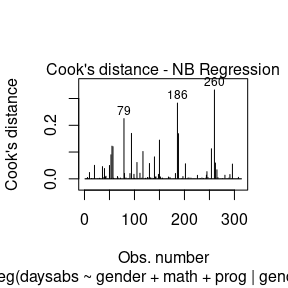

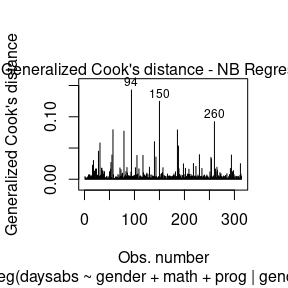

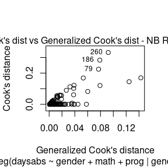

```r
plot(fit, which = c(3,4,5))
```

and

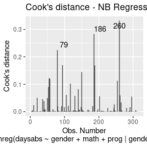

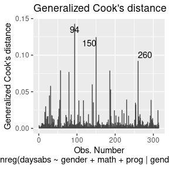

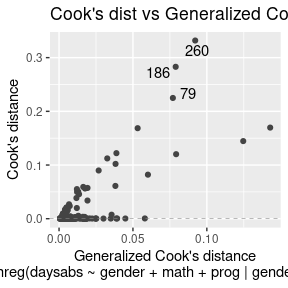

```r
autoplot(fit, which = c(3,4,5))
```

These plots identify the most extreme points. By the default they identify 3 points, but the number of identified points can be changed by setting the `id.n` argument to the desired value for the `plot` method and by setting the `label.n` argument to the desired value for the `autoplot` method:

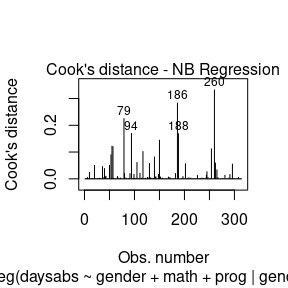

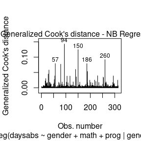

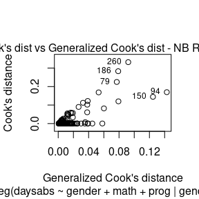

```r
plot(fit, which = c(3,4,5), id.n = 5)
```

and

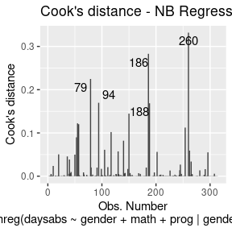

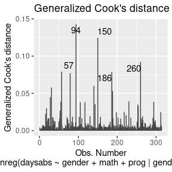

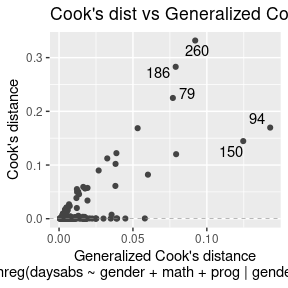

```r
autoplot(fit, which = c(3,4,5), label.n = 5)
```

For further details customizing plots of `mixpoissonreg` objects, we refer the reader to the Diagnostic plots with the *mixpoissonreg* package vignette.

We now turn to the problem of plotting Q-displacements and likelihood displacements. Both of these plots can easily be built “by hand”.

R’s base graphics:

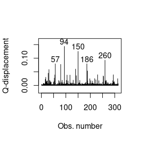

```r
qd_fit <- cooks.distance(fit, type = "QD")

# Get the extreme points:
extreme_points <- as.vector(Rfast::nth(abs(qd_fit), k = 5,
                                    num.of.nths = 5,
                                    index.return = TRUE, descending = TRUE))
idx_y <- qd_fit[extreme_points]

ylim <- range(qd_fit, na.rm = TRUE)

ylim <- extendrange(r = ylim, f = 0.15)

plot(qd_fit, xlab = "Obs. number", ylab = "Q-displacement", ylim = ylim, type = "h")
text(extreme_points, idx_y, labels = extreme_points, pos = 3, offset = 0.2)
```

and

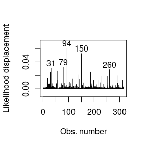

```r
ld_fit <- cooks.distance(fit, type = "LD")

# Get 5 most extreme points:
extreme_points <- as.vector(Rfast::nth(abs(ld_fit), k = 5,
                                    num.of.nths = 5,
                                    index.return = TRUE, descending = TRUE))
idx_y <- ld_fit[extreme_points]

ylim <- range(ld_fit, na.rm = TRUE)

ylim <- extendrange(r = ylim, f = 0.15)

plot(ld_fit, xlab = "Obs. number", ylab = "Likelihood displacement", ylim = ylim, type = "h")
text(extreme_points, idx_y, labels = extreme_points, pos = 3, offset = 0.2)
```

Now the `ggplot2` version:

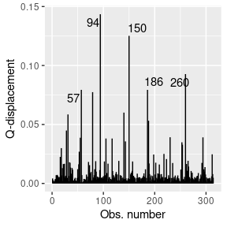

```r
library(dplyr)
library(ggplot2)
library(ggrepel)

qd_fit <- cooks.distance(fit, type = "QD")

qd_tbl <- tibble("Q-displacement" = qd_fit, "Obs. number" = 1:length(qd_fit))

# Get 5 most extreme points
qd.extreme <- arrange(qd_tbl, desc(`Q-displacement`))
qd.extreme <- head(qd.extreme, 5)

ggplot(qd_tbl, aes(x = `Obs. number`, y = `Q-displacement`)) +
  geom_linerange(aes(ymin = 0, ymax = `Q-displacement`)) +
  geom_text_repel(data = qd.extreme, aes(label = `Obs. number`))
```

and

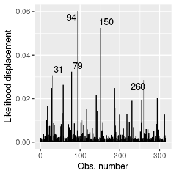

```r
ld_fit <- cooks.distance(fit, type = "LD")

ld_tbl <- tibble("Likelihood displacement" = ld_fit, "Obs. number" = 1:length(ld_fit))

# Get 5 most extreme points
ld.extreme <- arrange(ld_tbl, desc(`Likelihood displacement`))
ld.extreme <- head(ld.extreme, 5)

ggplot(ld_tbl, aes(x = `Obs. number`, y = `Likelihood displacement`)) +
  geom_linerange(aes(ymin = 0, ymax = `Likelihood displacement`)) +
  geom_text_repel(data = ld.extreme, aes(label = `Obs. number`))
```

# Local Influence

## Conformal normal curvature

### Direction of largest curvature

## Normal curvature

### Direction of largest curvature

## Perturbation schemes with respect to a subset of the covariates

# References

- Cook, R. D. and Weisberg, S. (1982) *Residuals and Influence in Regression.* New York and London: Chapman and Hall.